# Real estate market in USA

# Analisa Penjualan 2014

Penjualan Mei 2014

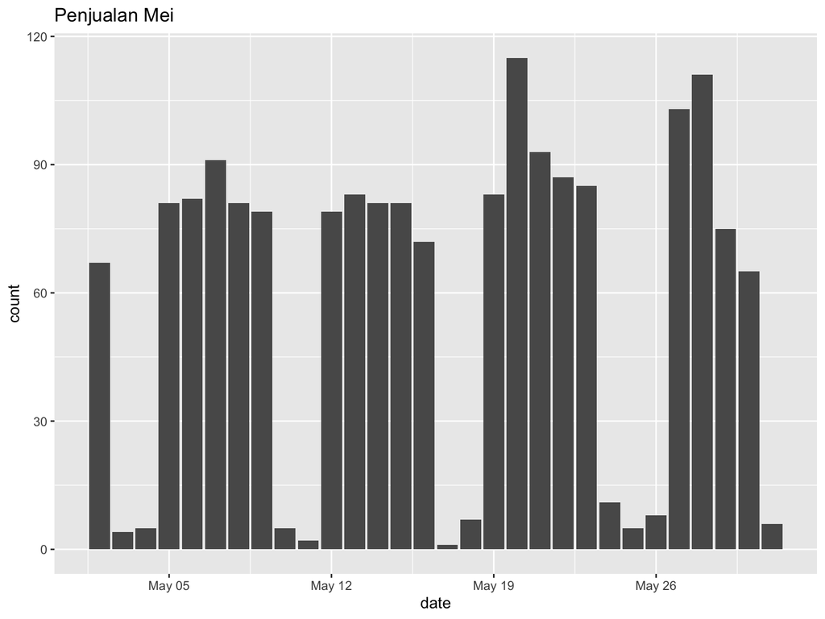

```r
ggplot(mei, mapping = aes(date)) +
  geom_bar() +
  labs(title="Penjualan Mei")
```

# Analisa Penjualan 2014

Grafik Penjualan berdasarkan minggu pada Mei 2014

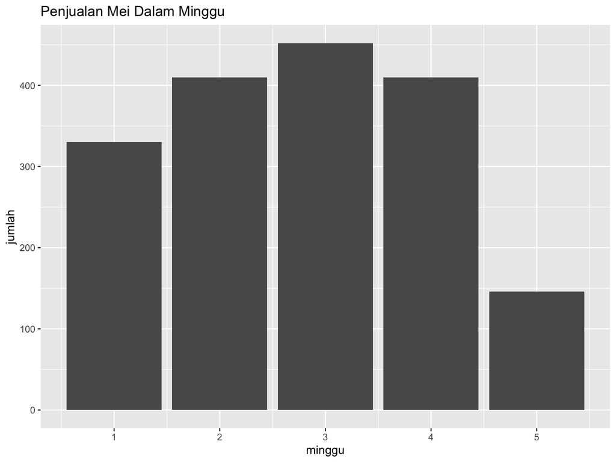

# Analisa Penjualan 2014

Grafik Penjualan berdasarkan hari pada minggu ke 3 di Mei 2014

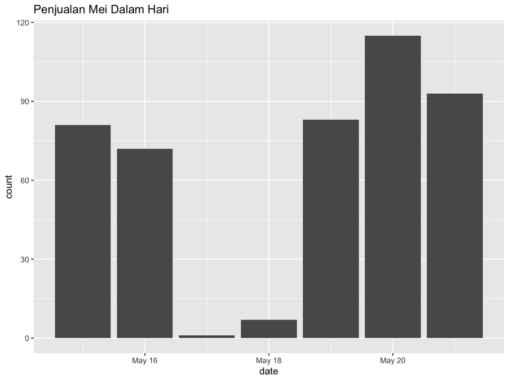

# Analisa Penjualan 2014

Penjualan Juni 2014

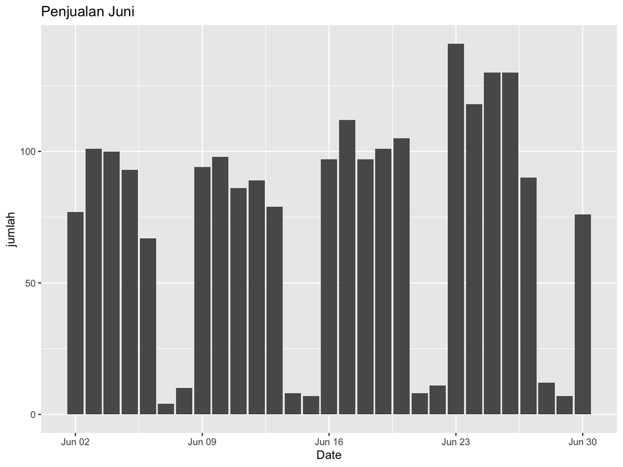

```r
ggplot(juni, aes(date)) +
  geom_bar(aes(fill = condition), stat = "count") +
  labs(title="Penjualan Juni", x="Date", y="jumlah")
```

# Analisa Penjualan 2014

Grafik Penjualan berdasarkan minggu pada Juni 2014

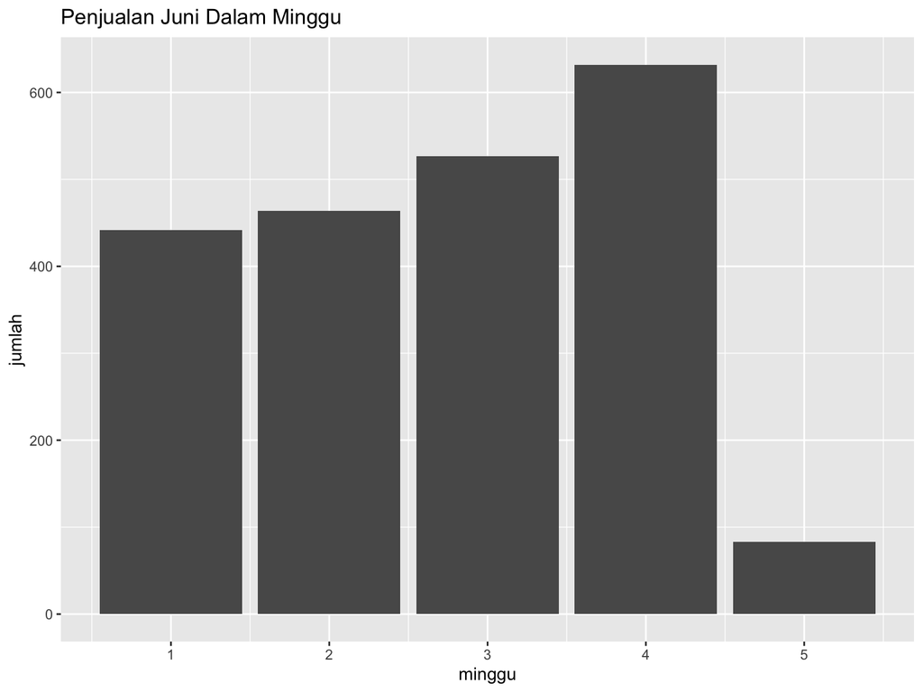

# Analisa Penjualan 2014

Grafik Penjualan berdasarkan hari pada minggu ke 4 di Juni 2014

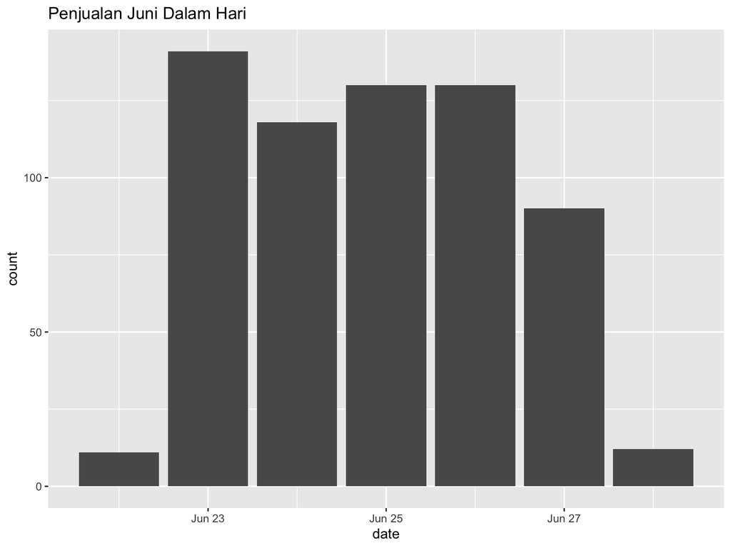

# Analisa Penjualan 2014

Penjualan Juli 2014

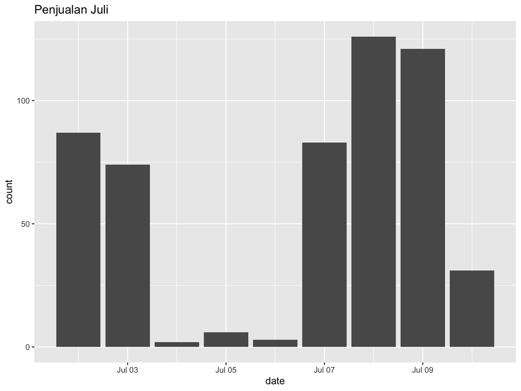

```r
ggplot(juli, mapping = aes(date)) +
  geom_bar(aes(fill = condition), position = "identity", stat = "count") +
  labs(title="Penjualan Juli")
```

# Analisa Penjualan 2014

Grafik Penjualan berdasarkan minggu pada Juli 2014

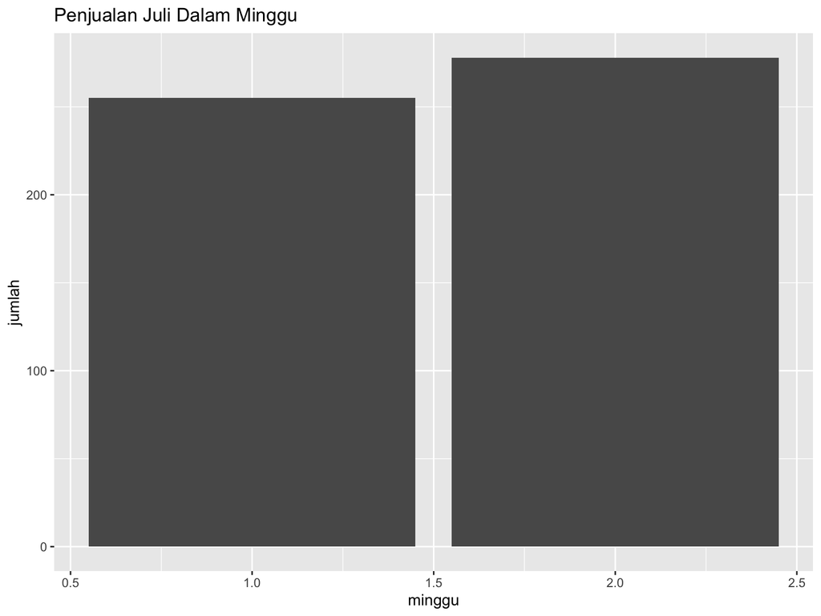

# Analisa Penjualan 2014

Grafik Penjualan berdasarkan hari pada minggu ke 2 di Juli 2014

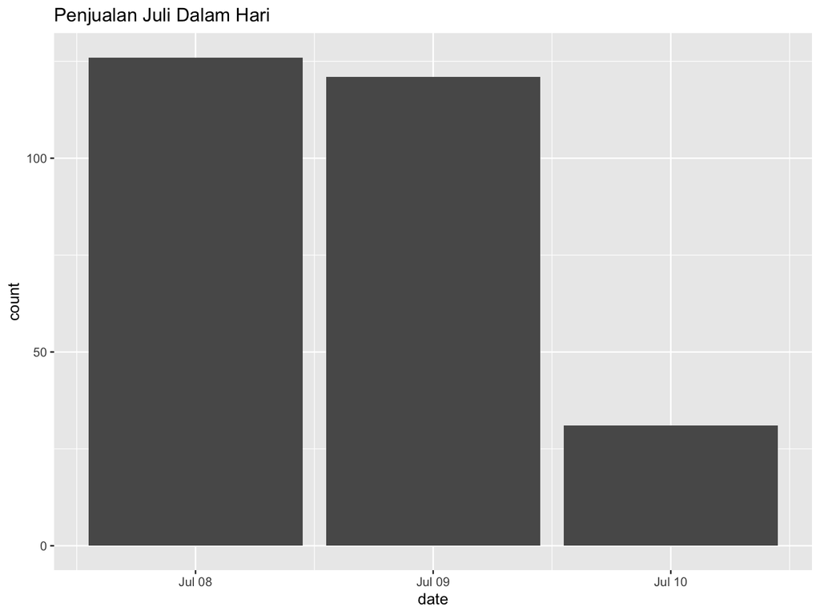

# Analisa Lokasi

Penjualan Terbanyak terdapat kota

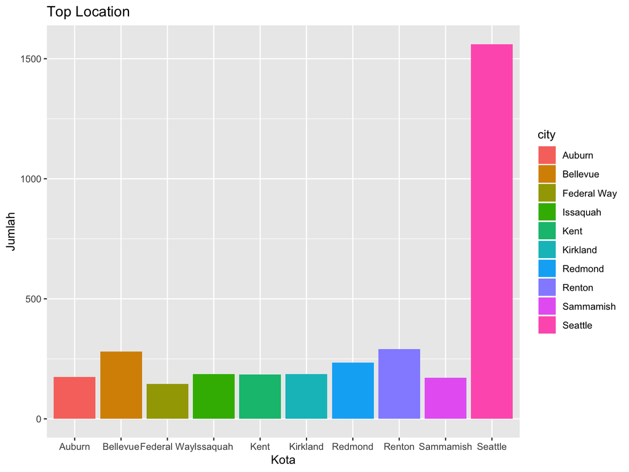